# Everyday Moments and The Mind

PSY 120L Reproducible Analysis Report

Author

Anna Moraru

Published

May 28, 2026

## About This Report

This report is a reproducible data analysis for the study “Everyday Moments and The Mind”. The report documents the data preparation, variable construction, data quality filtering, descriptive statistics, primary analyses, and data visualizations for this study.

The report is intended to accompany a manuscript-style research paper. It is not the full paper itself, instead, it shows how the reported analyses were produced from the raw dataset using a transparent and reproducible Quarto workflow.

## Study Overview

This study is a between-subjects design, which tests to examine whether the environmental condition of taking a brief outdoor break improves working memory performance, compared to an indoor environment, and whether working memory performance differs based on sex or perceived stress levels.

The design of this study has one independent variable, environmental condition and two moderators, stress and sex. The report includes the 2 x 2 ANOVA models that show how the environment conditions affects the dependent variable of working memory performance based on perceived stress levels and biological sex. The working memory performance is measured by an 8-level backward digit-span recall task.

## Setup and Software Environment

This section loads the packages used for data preparation, scale construction, statistical modeling, estimated marginal means, and figures.

**Load Packages**

```r
library(tidyverse)  # data manipulation + plotting
library(psych)      # scale construction + reliability
library(afex)       # ANOVA models + effect sizes
library(emmeans)    # estimated marginal means + confidence intervals
```

## Data Source and Analysis Dataset

The original dataset was imported from the project data folder. The imported dataset was stored as study_raw so that the original file remained unchanged throughout the report.

A smaller analysis dataset was created for the current analyses. This dataset retained the consent confirmations, study condition variables, demographic variables, backwards-digit span items and Perceived Stress Scale items needed for variable preparation and analysis.

### Import Dataset

```r
study_raw <- read_csv("data/NatureAndMind.csv")
```

### Check Imported Dataset

```r
dim(study_raw)
```

```
[1] 84 41
```

```r
names(study_raw)
```

```
 [1] "StartDate"
 [2] "EndDate"
 [3] "Duration (in seconds)"
 [4] "Finished"
 [5] "RecordedDate"
 [6] "Consent"
 [7] "Timing_Outdoor_First Click"
 [8] "Timing_Outdoor_Last Click"
 [9] "Timing_Outdoor_Page Submit"
[10] "Timing_Outdoor_Click Count"
[11] "Timing_Indoor_First Click"
[12] "Timing_Indoor_Last Click"
[13] "Timing_Indoor_Page Submit"
[14] "Timing_Indoor_Click Count"
[15] "QID34"
```

[output cut: 26 more lines]

```r
head(study_raw)
```

| StartDate | EndDate | Duration (in seconds) | Finished | RecordedDate | Consent | Timing_Outdoor_First Click | Timing_Outdoor_Last Click | Timing_Outdoor_Page Submit | Timing_Outdoor_Click Count | Timing_Indoor_First Click | Timing_Indoor_Last Click | Timing_Indoor_Page Submit | Timing_Indoor_Click Count | QID34 | Break_First Click | Break_Last Click | Break_Page Submit | Break_Click Count | Answer1 | Answer2 | Answer3 | Answer4 | Answer5 | Answer6 | Answer7 | Answer8 | PSS_1 | PSS_2 | PSS_3 | … |
| --- | --- | --- | --- | --- | --- | --- | --- | --- | --- | --- | --- | --- | --- | --- | --- | --- | --- | --- | --- | --- | --- | --- | --- | --- | --- | --- | --- | --- | --- | --- |
| 5/7/2026 12:14 | 5/7/2026 12:30 | 910 | 1 | 5/7/2026 12:30 | 1 | NA | NA | NA | NA | 0.000 | 0.000 | 420.025 | 0 | Moderate to darker lighting. My bedroom smells like sesame seed oil, slightly musty. My roommate's stuff is in a giant heaping mess on her half of the room. The overall vibe of the room is calming and… | NA | NA | NA | NA | 71 | 285 | 9346 | 724 | NA | NA | NA | NA | 2 | 1 | 3 | … |
| 5/7/2026 13:01 | 5/7/2026 13:12 | 648 | 1 | 5/7/2026 13:12 | 1 | NA | NA | NA | NA | 0.000 | 0.000 | 420.023 | 0 | i observed my couch and tv the smell of vanilla from a candel burining, saw some dirt on the floor and dust of the tv stand. the temp was pretty neutral but i could have used a blanket because my feet… | NA | NA | NA | NA | 71 | 258 | NA | NA | NA | NA | NA | NA | 2 | 2 | 4 | … |
| 5/7/2026 16:39 | 5/7/2026 17:00 | 1310 | 1 | 5/7/2026 17:00 | 1 | NA | NA | NA | NA | 0.757 | 1.060 | 39.879 | 2 | I just got back from the beach so I was quite dehydrated. To preface I walked from my living room to my room- the door was open, breeze was nice, birds were chirping, really made me contemplate what I… | NA | NA | NA | NA | 71 | 285 | 9346 | 13724 | 379146 | NA | NA | NA | 1 | 1 | 2 | … |
| 5/7/2026 19:34 | 5/7/2026 19:54 | 1191 | 1 | 5/7/2026 19:54 | 1 | NA | NA | NA | NA | 5.929 | 8.733 | 419.901 | 2 | I noticed that the room I went to was less lit and the floor was softer compared to the room I was previously in. The walls were more minimal with less photos and art. The temperature was cooler. | NA | NA | NA | NA | 71 | 285 | 9346 | 13724 | 37496 | NA | NA | NA | 3 | 3 | 2 | … |
| 5/7/2026 22:33 | 5/7/2026 22:49 | 926 | 1 | 5/7/2026 22:49 | 1 | NA | NA | NA | NA | 6.931 | 6.931 | 419.901 | 1 | I’ve observed a tickling in my feet, and my brain jumping between thoughts. I also noticed that lots of muscles were tensioned without me realizing.\n\nI’ve heard street noises as cars passing by, voi… | NA | NA | NA | NA | 71 | 285 | 9346 | 13724 | 37196 | NA | NA | NA | 1 | 2 | 3 | … |
| 5/7/2026 23:15 | 5/7/2026 23:29 | 872 | 1 | 5/7/2026 23:29 | 1 | NA | NA | NA | NA | 4.926 | 324.717 | 419.919 | 3 | i have beautiful flashing color lights and i have been watching how that looks on the patterns of the carpet on the rug on my bedroom floor and my fan is spinning around and it feels nice and the room… | NA | NA | NA | NA | 71 | 285 | 46 | NA | NA | NA | NA | NA | 3 | 3 | 4 | … |

The import checks confirm that the raw dataset loaded successfully, show the number of rows and columns, and display the variable names available in the original dataset.

### Create Analysis Dataset

```r
study_vars <- c(
  "Condition", "Sex", "Age", "Finished", "Consent",

  "Answer1", "Answer2", "Answer3", "Answer4",
  "Answer5", "Answer6", "Answer7", "Answer8",

  "PSS_1", "PSS_2", "PSS_3", "PSS_4r", "PSS_5r",
  "PSS_6", "PSS_7r", "PSS_8r", "PSS_9", "PSS_10"
)

study_data <- study_raw %>%
  select(all_of(study_vars)) %>%

    filter(Finished == 1 & !is.na(Finished)) %>%
  filter(Consent == 1 & !is.na(Consent)) %>%

    mutate(
    across(where(is.numeric), as.numeric)
  )

study_data %>%
  count(Condition) %>%
  knitr::kable(
    col.names = c("Environment Condition", "n")
  )
```

| Environment Condition | n |
| --- | --- |
| Indoor | 43 |
| Outdoor | 40 |

### Check Analysis Dataset

```r
length(study_vars)
```

```
[1] 23
```

```r
dim(study_data)
```

```
[1] 83 23
```

```r
names(study_data)
```

```
 [1] "Condition" "Sex"       "Age"       "Finished"  "Consent"   "Answer1"
 [7] "Answer2"   "Answer3"   "Answer4"   "Answer5"   "Answer6"   "Answer7"
[13] "Answer8"   "PSS_1"     "PSS_2"     "PSS_3"     "PSS_4r"    "PSS_5r"
[19] "PSS_6"     "PSS_7r"    "PSS_8r"    "PSS_9"     "PSS_10"
```

The analysis dataset contains the variables required for the report. The checks confirm the number of selected variables, the dimensions of the analysis dataset, and the final variable names carried forward into the preparation and analysis sections. It verifies that all data in the non-raw dataset is data that was completed and consented for use.

## Variable Preparation

This section prepares the variables used in the primary analyses. The original imported dataset was left unchanged; all prepared variables were created in the working analysis dataset named study_data.

### Prepare Participant ID and Experimental Condition

```r
study_data <- study_data %>%
  mutate(
    id = row_number(),
    Condition = factor(Condition),
    Sex = factor(Sex, levels = c(1, 2), labels = c("Male", "Female"))
  )
```

The biological sex variable was recoded as a labeled factor with two levels: Male and Female, and environmental condition maintained to be: Indoor and Outdoor. A participant ID variable was also created so that each row in the analysis dataset had a unique identifier.

### Check Experimental Condition Coding

```r
study_data %>%
  count(Condition) %>%
  knitr::kable(
    col.names = c("Environment Condition", "n")
  )
```

| Environment Condition | n |
| --- | --- |
| Indoor | 43 |
| Outdoor | 40 |

The condition check confirms the number of participants assigned to each environment condition.

### Check Prepared Analysis Dataset

```r
dim(study_data)
```

```
[1] 83 24
```

```r
names(study_data)
```

```
 [1] "Condition" "Sex"       "Age"       "Finished"  "Consent"   "Answer1"
 [7] "Answer2"   "Answer3"   "Answer4"   "Answer5"   "Answer6"   "Answer7"
[13] "Answer8"   "PSS_1"     "PSS_2"     "PSS_3"     "PSS_4r"    "PSS_5r"
[19] "PSS_6"     "PSS_7r"    "PSS_8r"    "PSS_9"     "PSS_10"    "id"
```

The prepared analysis dataset contains the variables needed for scale construction, descriptive statistics, and primary analyses. This makes sure all of the variables are present before analysis.

### Score Backward Digit Span

```r
answer_cols <- paste0("Answer", 1:8)
correct_answer8 <- "485268572"

study_data <- study_data %>%
  mutate(
    Answer8_clean = str_remove(as.character(Answer8), "\\.0$"),
    span_score = 8 - rowSums(
      across(
        all_of(answer_cols),
        ~ is.na(.x) | str_trim(as.character(.x)) == ""
      )
    ),
    span_score = if_else(
      span_score == 8 & Answer8_clean == correct_answer8,
      9,
      span_score
    )
  ) %>%
  filter(span_score != 0)
```

### Check Backward Digit Span Scores

```r
study_data %>%
  count(span_score) %>%
  knitr::kable(
    col.names = c("Backward Digit Span Score", "n")
  )
```

| Backward Digit Span Score | n |
| --- | --- |
| 1 | 9 |
| 2 | 8 |
| 3 | 10 |
| 4 | 22 |
| 5 | 23 |
| 6 | 6 |
| 7 | 4 |
| 9 | 1 |

```r
summary(study_data$span_score)
```

```
   Min. 1st Qu.  Median    Mean 3rd Qu.    Max.
  1.000   3.000   4.000   3.988   5.000   9.000
```

### Reverse-Code Scale Items

Items requiring reverse coding were transformed before scale scores were computed. Because the items used a 0–4 response scale, reverse-coded items were created by subtracting each original item response from 4.

```r
study_data <- study_data %>%
  mutate(
    PSS_4reverse = 4 - PSS_4r,
    PSS_5reverse = 4 - PSS_5r,
    PSS_7reverse = 4 - PSS_7r,
    PSS_8reverse = 4 - PSS_8r
  )
```

### Check Reverse Coding

```r
study_data %>%
  select(
    PSS_4r, PSS_4reverse,
    PSS_5r, PSS_5reverse,
    PSS_7r, PSS_7reverse,
    PSS_8r, PSS_8reverse
  ) %>%
  head(10) %>%
  knitr::kable()
```

| PSS_4r | PSS_4reverse | PSS_5r | PSS_5reverse | PSS_7r | PSS_7reverse | PSS_8r | PSS_8reverse |
| --- | --- | --- | --- | --- | --- | --- | --- |
| 3 | 1 | 3 | 1 | 3 | 1 | 2 | 2 |
| 3 | 1 | 3 | 1 | 2 | 2 | 3 | 1 |
| 3 | 1 | 3 | 1 | 1 | 3 | 2 | 2 |
| 4 | 0 | 2 | 2 | 2 | 2 | 4 | 0 |
| 4 | 0 | 4 | 0 | 2 | 2 | 4 | 0 |
| 2 | 2 | 3 | 1 | 3 | 1 | 1 | 3 |
| 2 | 2 | 1 | 3 | 2 | 2 | 2 | 2 |
| 2 | 2 | 2 | 2 | 2 | 2 | 3 | 1 |
| 3 | 1 | 2 | 2 | 3 | 1 | 1 | 3 |
| 2 | 2 | 2 | 2 | 1 | 3 | 2 | 2 |

### Create Scale Scores

Scale item lists were defined and used to compute perceived stress scores.

```r
pss_items <- c(
  "PSS_1", "PSS_2", "PSS_3",
  "PSS_4reverse", "PSS_5reverse", "PSS_6",
  "PSS_7reverse", "PSS_8reverse", "PSS_9", "PSS_10"
)

study_data <- study_data %>%
  mutate(
    stress_scale = rowMeans(
      across(all_of(pss_items)),
      na.rm = TRUE
    ),
    stress_total = rowSums(
      across(all_of(pss_items)),
      na.rm = TRUE
    )
  )
```

### Check Scale Scores

```r
study_data %>%
  select(
    stress_scale,
    stress_total
  ) %>%
  summary()
```

```
  stress_scale    stress_total
 Min.   :0.300   Min.   : 3.00
 1st Qu.:1.600   1st Qu.:16.00
 Median :1.900   Median :19.00
 Mean   :1.931   Mean   :19.31
 3rd Qu.:2.400   3rd Qu.:24.00
 Max.   :3.100   Max.   :31.00
```

```r
study_data %>%
  summarise(
    stress_scale_missing = mean(is.na(stress_scale)),
    stress_total_missing = mean(is.na(stress_total))
  ) %>%
  knitr::kable()
```

| stress_scale_missing | stress_total_missing |
| --- | --- |
| 0 | 0 |

The scale-score checks confirm that the computed scale scores fall within the expected response range and show whether any scale scores are missing.

```r
stress_median <- median(study_data$stress_scale, na.rm = TRUE)

study_data <- study_data %>%
  mutate(
    stress_group = if_else(
      stress_scale <= stress_median,
      "Low Stress",
      "High Stress"
    ),
    stress_group = factor(
      stress_group,
      levels = c("Low Stress", "High Stress")
    )
  )

stress_median
```

```
[1] 1.9
```

```r
study_data %>%
  count(stress_group) %>%
  knitr::kable(
    col.names = c("Perceived Stress Group", "n")
  )
```

| Perceived Stress Group | n |
| --- | --- |
| Low Stress | 43 |
| High Stress | 40 |

### Check Scale Reliability

Internal consistency was estimated for the perceived stress scales before the scale scores were used in the primary analyses.

```r
stress_item_df <- study_data %>%
  select(all_of(pss_items))

stress_alpha <- psych::alpha(stress_item_df)

stress_omega <- psych::omega(stress_item_df, plot = FALSE)

reliability_table <- tibble(
  scale = c("Perceived Stress"),
  alpha = c(stress_alpha$total$raw_alpha),
  omega = c(stress_omega$omega.tot)
)

reliability_table %>%
  mutate(
    alpha = round(alpha, 2),
    omega = round(omega, 2)
  ) %>%
  knitr::kable(
    col.names = c("Scale", "Cronbach's alpha", "McDonald's omega")
  )
```

| Scale | Cronbach’s alpha | McDonald’s omega |
| --- | --- | --- |
| Perceived Stress | 0.82 | 0.86 |

The reliability table reports Cronbach’s alpha and McDonald’s omega metrics for the scale used in the analysis. Cronbach’s alpha and McDonald’s omega confirm internal consistency.

## Descriptive Statistics

This section summarizes the scale scores and sample composition before the primary hypothesis tests.

### Scale Score Descriptives

```r
study_data %>%
  select(span_score, stress_scale, stress_total) %>%
  psych::describe() %>%
  knitr::kable(digits = 2)
```

|  | vars | n | mean | sd | median | trimmed | mad | min | max | range | skew | kurtosis | se |
| --- | --- | --- | --- | --- | --- | --- | --- | --- | --- | --- | --- | --- | --- |
| span_score | 1 | 83 | 3.99 | 1.68 | 4.0 | 4.00 | 1.48 | 1.0 | 9.0 | 8.0 | -0.01 | -0.06 | 0.18 |
| stress_scale | 2 | 83 | 1.93 | 0.59 | 1.9 | 1.94 | 0.59 | 0.3 | 3.1 | 2.8 | -0.12 | -0.38 | 0.06 |
| stress_total | 3 | 83 | 19.31 | 5.89 | 19.0 | 19.36 | 5.93 | 3.0 | 31.0 | 28.0 | -0.12 | -0.38 | 0.65 |

The table reports descriptive statistics for the stress scale scores used in the primary analyses, including sample size, mean values, median values, standard deviations, skew and more.

### Sample Composition by Age and Gender

```r
study_data %>%
  count(Age) %>%
  mutate(percent = round(100 * n / sum(n), 1)) %>%
  knitr::kable(
    col.names = c("Age Group", "n", "Percent")
  )
```

| Age Group | n | Percent |
| --- | --- | --- |
| 1 | 1 | 1.2 |
| 2 | 77 | 92.8 |
| 3 | 5 | 6.0 |

```r
study_data %>%
  count(Sex) %>%
  mutate(percent = round(100 * n / sum(n), 1)) %>%
  knitr::kable(
    col.names = c("Sex", "n", "Percent")
  )
```

| Sex | n | Percent |
| --- | --- | --- |
| Male | 27 | 32.5 |
| Female | 56 | 67.5 |

The table reports the number and percentage of participants in each sex category.

## Correlations Among the DVs

A Pearson correlation coefficient was calculated to examine the relationship between working memory span values and perceived stress scale.

```r
correlation_results <- psych::corr.test(
  study_data %>%
    select(span_score, stress_scale),
  use = "pairwise"
)

correlation_results$r
```

```
              span_score stress_scale
span_score    1.00000000  -0.09455112
stress_scale -0.09455112   1.00000000
```

```r
correlation_results$p
```

```
             span_score stress_scale
span_score    0.0000000    0.3951889
stress_scale  0.3951889    0.0000000
```

## Primary Analyses

This section reports the primary analyses used to test whether environmental condition, stress, biological sex, or their interaction predicted backward digit-span scores.

2 × 2 ANOVA models were constructed. The first model tests impact of environmental condition and biological sex on working memory. The second model tests the impact of the environmental condition and perceived stress levels on working memory.

Both models used backward digit-span scores as the dependent variable. In both models, the environmental condition was the manipulated independent variable, as biological sex and stress were the categorical moderators.

### Environment Condition × Sex Model

```r
table(study_data$Condition)
```

```
 Indoor Outdoor
     43      40
```

```r
a1_span_sex <- afex::aov_ez(
  id = "id",
  dv = "span_score",
  between = c("Condition", "Sex"),
  data = study_data
)

a1_span_sex
```

```
Anova Table (Type 3 tests)

Response: span_score
         Effect    df  MSE    F  ges p.value
1     Condition 1, 79 2.77 0.20 .003    .654
2           Sex 1, 79 2.77 1.00 .012    .322
3 Condition:Sex 1, 79 2.77 2.42 .030    .123
---
Signif. codes:  0 '***' 0.001 '**' 0.01 '*' 0.05 '+' 0.1 ' ' 1
```

### Estimated Means for Environment Condition × Sex

```r
emmeans(a1_span_sex, ~ Condition)
```

```
 Condition emmean    SE df lower.CL upper.CL
 Indoor      3.82 0.266 79     3.29     4.35
 Outdoor     4.00 0.287 79     3.43     4.57

Results are averaged over the levels of: Sex
Confidence level used: 0.95
```

```r
emmeans(a1_span_sex, ~ Sex)
```

```
 Sex    emmean    SE df lower.CL upper.CL
 Male     3.72 0.322 79     3.08     4.36
 Female   4.11 0.222 79     3.66     4.55

Results are averaged over the levels of: Condition
Confidence level used: 0.95
```

```r
emmeans(a1_span_sex, ~ Condition * Sex)
```

```
 Condition Sex    emmean    SE df lower.CL upper.CL
 Indoor    Male     3.93 0.430 79     3.08     4.79
 Outdoor   Male     3.50 0.480 79     2.54     4.46
 Indoor    Female   3.71 0.314 79     3.09     4.34
 Outdoor   Female   4.50 0.314 79     3.87     5.13

Confidence level used: 0.95
```

### Environment Condition × Perceived Stress Group Model

```r
a2_span_stress <- afex::aov_ez(
  id = "id",
  dv = "span_score",
  between = c("Condition", "stress_group"),
  data = study_data
)

a2_span_stress
```

```
Anova Table (Type 3 tests)

Response: span_score
                  Effect    df  MSE    F   ges p.value
1              Condition 1, 79 2.87 1.24  .015    .269
2           stress_group 1, 79 2.87 0.00 <.001    .989
3 Condition:stress_group 1, 79 2.87 0.25  .003    .621
---
Signif. codes:  0 '***' 0.001 '**' 0.01 '*' 0.05 '+' 0.1 ' ' 1
```

### Estimated Means for Environment Condition × Perceived Stress Group

```r
emmeans(a2_span_stress, ~ Condition)
```

```
 Condition emmean    SE df lower.CL upper.CL
 Indoor      3.78 0.260 79     3.26     4.30
 Outdoor     4.20 0.268 79     3.66     4.73

Results are averaged over the levels of: stress_group
Confidence level used: 0.95
```

```r
emmeans(a2_span_stress, ~ stress_group)
```

```
 stress_group emmean    SE df lower.CL upper.CL
 Low Stress     3.99 0.260 79     3.47     4.51
 High Stress    3.98 0.268 79     3.45     4.52

Results are averaged over the levels of: Condition
Confidence level used: 0.95
```

```r
emmeans(a2_span_stress, ~ Condition * stress_group)
```

```
 Condition stress_group emmean    SE df lower.CL upper.CL
 Indoor    Low Stress     3.88 0.346 79     3.19     4.56
 Outdoor   Low Stress     4.11 0.389 79     3.33     4.88
 Indoor    High Stress    3.68 0.389 79     2.91     4.46
 Outdoor   High Stress    4.29 0.370 79     3.55     5.02

Confidence level used: 0.95
```

## Figures

This section creates the figures used to visualize the primary 2 × 2 ANOVA results. The figures are based on the estimated cell means from the ANOVA models.

### Span Score x Sex Interaction Plot

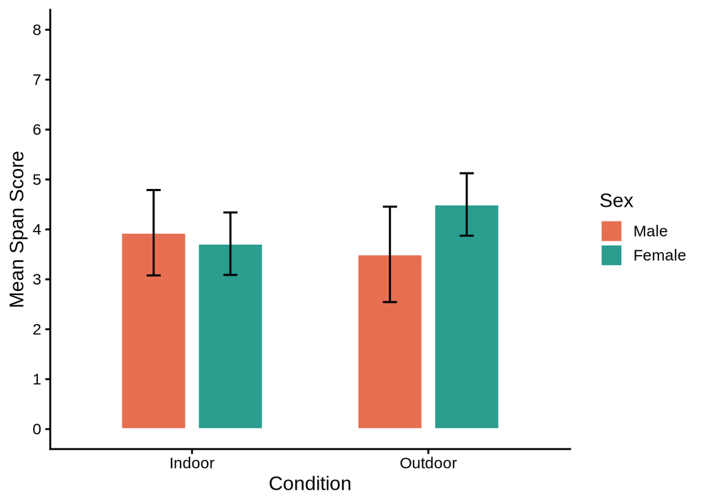

```r
p_span_condition_sex_bar <- ggplot(
  as.data.frame(emmeans(a1_span_sex, ~ Condition * Sex)),
  aes(
    x = Condition,
    y = emmean,
    fill = Sex
  )
) +
  geom_col(
    position = position_dodge(width = 0.65),
    width = 0.55,
    color = "white"
  ) +
  geom_errorbar(
    aes(
      ymin = lower.CL,
      ymax = upper.CL
    ),
    position = position_dodge(width = 0.65),
    width = 0.12,
    linewidth = 0.7
  ) +
  labs(
    x = "Condition",
    y = "Mean Span Score",
    fill = "Sex"
  ) +
  scale_fill_manual(
    values = c(
      "Male" = "#E76F51",
      "Female" = "#2A9D8F"
    )
  ) +
  scale_y_continuous(
    breaks = seq(0, 8, 1)
  ) +
  coord_cartesian(
    ylim = c(0, 8)
  ) +
  theme_classic(
    base_size = 14
  )

p_span_condition_sex_bar
```

The chart map shows the working memory performance trends across indoor and outdoor environments split by biological sex, male and female. The error bars display the 95% confidence intervals. Although the main effects of environmental condition and sex, as well as interaction effect is not significant, there is a trend that shows the average of female participants in the outdoor condition have slightly higher mean span scores compared to males, and compared to females in the indoor condition.

### Span Score × Stress Interaction Plot

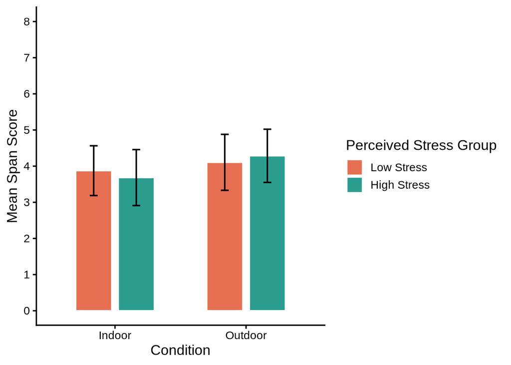

```r
p_span_condition_stress_bar <- ggplot(
  as.data.frame(emmeans(a2_span_stress, ~ Condition * stress_group)),
  aes(
    x = Condition,
    y = emmean,
    fill = stress_group
  )
) +
  geom_col(
    position = position_dodge(width = 0.65),
    width = 0.55,
    color = "white"
  ) +
  geom_errorbar(
    aes(
      ymin = lower.CL,
      ymax = upper.CL
    ),
    position = position_dodge(width = 0.65),
    width = 0.12,
    linewidth = 0.7
  ) +
  labs(
    x = "Condition",
    y = "Mean Span Score",
    fill = "Perceived Stress Group"
  ) +
  scale_fill_manual(
    values = c(
      "Low Stress" = "#E76F51",
      "High Stress" = "#2A9D8F"
    )
  ) +
  scale_y_continuous(
    breaks = seq(0, 8, 1)
  ) +
  coord_cartesian(
    ylim = c(0, 8)
  ) +
  theme_classic(
    base_size = 14
  )

p_span_condition_stress_bar
```

The chart map shows the working memory performance trends across indoor and outdoor environments split by low or high level of perceived stress. The error bars display the 95% confidence intervals. Although the main effects of environmental condition and stress, and interaction effect is not significant, there is a trend that shows a slight higher average in mean span scores in the outdoor condition compared to the indoor condition for both low and high perceived stress groups.

### Export Figures

```r
if (!dir.exists("figures")) {
  dir.create("figures")
}

ggsave(
  filename = "figures/span_condition_sex_interaction_plot.svg",
  plot = p_span_condition_sex_bar,
  width = 7,
  height = 5
)

ggsave(
  filename = "figures/span_condition_stress_interaction_plot.svg",
  plot = p_span_condition_stress_bar,
  width = 7,
  height = 5
)
```

This saves the figures to be available for use. We included this in our presentation and research poster.

## Results Summary

The primary analyses tested whether environmental conditions, participant biological sex, baseline perceived stress or their interactions significantly impacted working memory performance. Two 2 x 2 between-subject ANOVA models were conducted to test our hypothesis.

The first model comparing environmental condition and sex had the main effects and interaction effects that were not statistically significant. The second model comparing environmental condition and stress also had the main effects and interaction effects that were not statistically significant. Participants randomly assigned to the outdoor break environmental condition did not significantly differ in their backward digit-span scores compared to those assigned to the indoor break environmental condition. The backward digit-span scores also did not significantly differ based on biological sex or levels of perceived stress. The interaction between environmental condition and biological sex was not statistically significant. Likewise, the interaction between environmental condition and perceived stress were also not statistically significant, indicating that working memory performance did not meaningfully vary across biological sex or levels of perceived stress.

These results do not support the study’s hypothesis. Despite absence of statistical significance, there is a descriptive trend that females averaged with higher span scores compared to males, and that individuals in both stress levels averaged slightly higher span scores in an outdoor break environmental condition break than indoor break environmental condition.